# Panel Data Regression Using R (Using RStudio)

Panel Data Regression Using R (Using RStudio)

This guide shows how to do a simplified Panel Data Regression analysis using RStudio. Panel data regression is a little different to the usual simple linear regression or multiple regression, since it often includes data, such as financial data, that changes over time for specific entities (like companies or countries).

## Example

[figure not shown]

Notice how the data are formatted. Each row represents one set of observations (in this case one year’s data) for each bank. Therefore we need two additional variables that identify the bank (bank_id) and the year (years) the data comes from. This way of arranging the data is called “Long Format”. The data needs to be in this long format and not “Wide Format” where you have each year’s data in separate columns which is often how the data are presented in tables or when extracted from financial databases.

There are also variables for BoardSize, FirmSize, FrequencyofBoardMeeting, tot_asset_trill, and Equity_trill, which can vary from year to year within each bank. These are our predictor variables also referred to as independent variables. The dependent variable is Tobin’s Q since we are interested in how this depends on (are affected by) the other (predictor or independent) variables.

## Importing the data into R

To get started with the analysis, first, bring the dataset into RStudio. To do this you can either run a read.csv() function if you know how to do this or alternatively you can follow the following steps using the menus:

From the **File** menu select **Import Dataset** then **From Text(base)**:

[figure not shown]

From the pop-up window navigate to the folder **where you have saved the dataset**, then once the file was selected click “Open”:

[figure not shown]

At the next dialogue box (see below), in the upper left corner in the **“Name”** field, amend the name of your dataset if you wish, in this example we named it as **“panel_data”**.

We should also make sure the **Heading** option below is set to **Yes** (otherwise the data will all be read in as text):

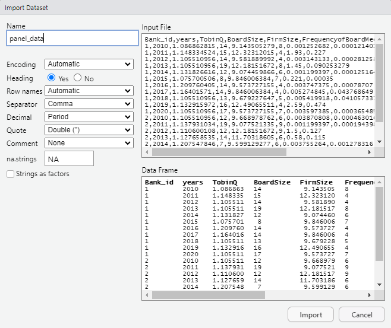

Finally, click on **“Import”** to complete the process. This imports the data set and is listed in the **“Environment”** in the top right of your RStudio screen as follows:

[figure not shown]

## Running a panel regression in RStudio

### Step 1: Initial Data Visualization

We should always first explore our data visually, to assess the potential value of a panel regression model. Particularly useful is to analyse the relationship between our dependent variable, e.g. Tobin’s q and our main independent variables, particularly Equity_trill and Total_asset_trill. We can do that by generating **scatter plots**:

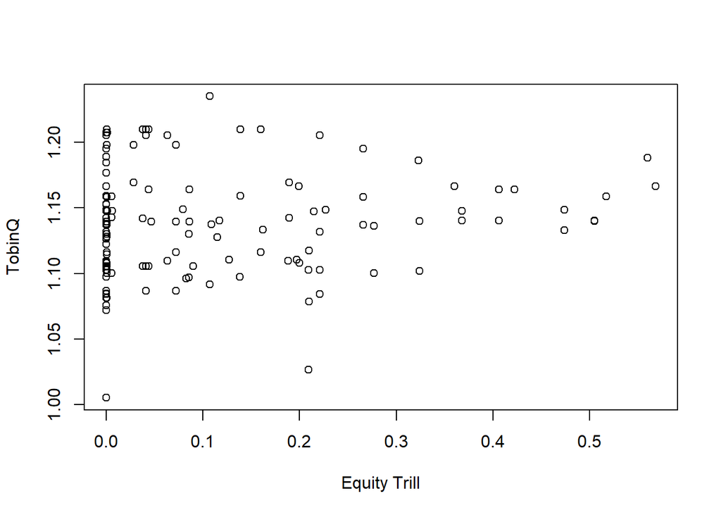

```r
plot(panel_data$Equity_trill, panel_data$TobinQ,
     xlab="Equity Trill",
     ylab="TobinQ")
```

Note: To generate plots in R, we need to indicate the data or variables we want to plot. We can do that by indicating which columns in our dataset contain that data, for the case of Rstudio, we can type the name of our dataset followed by a dollar sign **“$”** and the name of our column that contains the data as in the snippet of code above. Additionally, to add labels, we can add them by using the xlab and ylab options inside the function as seen in the code provided.

Repeat, this time putting tot_asset_trill in the X-Axis box to get:

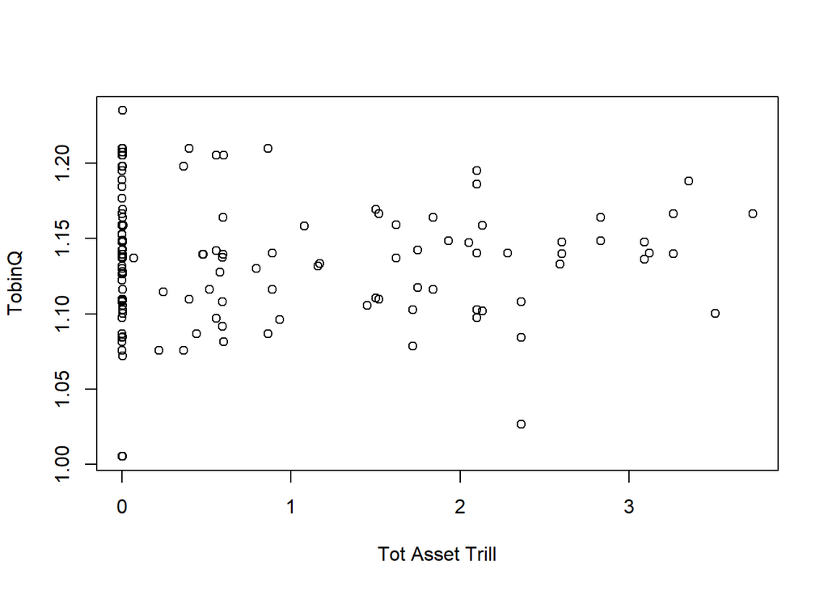

```r
plot(panel_data$tot_asset_trill, panel_data$TobinQ,
     xlab="Tot Asset Trill",
     ylab="TobinQ")
```

We can then repeat for all the other predictor variables.

In these graphs, we’re trying to spot trends or patterns in the data. A common thing we look for is whether there’s a linear relationship between the variables. Imagine you’re trying to draw a straight line through the data points. It can sometimes be tricky to determine this just by looking, but it’s a helpful first step to understanding your data.

### Step 2: Panel Data Regression

In panel data regression, it’s essential to control for specific unobserved effects that are specific to each bank and remain fairly constant over time. Examples might be the types of customers each bank attracts, as some may attract younger customers and some older customers. Another example might be the types of financial products the bank trades in. These might differ between banks but stay relatively constant over time but may explain some of the differences in Tobin’s Q.

Whilst RStudio can’t handle advanced panel regression models very easily, we can use it to implement a fixed effects regression technique for panel regression. Whilst this is somewhat limited for panel data regression, this approach offers a practical and scientifically sound method for panel data analysis.

We will approach the panel regression using a **Generalised Linear Model (GLM)**. First, we need to convert the variables **Bank_id** and **years** to factors so that they are recognised as categorical. These two types of variables are essential in panel data regression; one tells us about the individual entity (in this case, banks) and the other about the time period linking the same data to each bank together.

```r
panel_data$Bank_id <- as.factor(panel_data$Bank_id)
panel_data$years <- as.factor(panel_data$years)
```

To gain a better understanding of the data, we obtain descriptive statistics for each variable by using the **summary()** function:

```r
summary(panel_data)
```

Next, we can fit a GLM to our data using the **glm()** function. We put our dependent variable, **TobinQ** first, followed by our independent variables. Also make sure to specify the dataset name. To visually see our results, we obtain a **summary** of the model.

```r
glm_model <- glm(TobinQ ~ BoardSize + FirmSize + FrequencyofBoardMeeting + tot_asset_trill + Equity_trill + Bank_id + years, data = panel_data)
summary(glm_model)
```

### Step 3: Results

The descriptive statistics tell us information about the data. For the categorical variables, they provides information about how many individuals, , banks in our example, are in the sample. For the continuous variables, we can see key summary statistics, including the mean values for each variable.

[output not shown]

The column labelled **Estimate** gives us what are sometimes called the “beta coefficients” which describe the relationship each predictor has with Tobin’s Q. The column labelled **Pr(>|t|)** gives the associated p-value which tells us if there is evidence each relationship is statistically significant (i.e. represents a true relationship and not just a random chance relationship).

```
##
## Call:
## glm(formula = TobinQ ~ BoardSize + FirmSize + FrequencyofBoardMeeting +
##     tot_asset_trill + Equity_trill + Bank_id + years, data = panel_data)
##
## Coefficients:
##                           Estimate Std. Error t value Pr(>|t|)
## (Intercept)              1.1643710  0.0499568  23.308  < 2e-16 ***
## BoardSize               -0.0002501  0.0014293  -0.175  0.86137
## FirmSize                -0.0036726  0.0047572  -0.772  0.44156
## FrequencyofBoardMeeting  0.0010371  0.0019865   0.522  0.60254
## tot_asset_trill         -0.0233459  0.0118193  -1.975  0.05045 .
## Equity_trill             0.2164053  0.0715306   3.025  0.00302 **
## Bank_id2                 0.0275815  0.0177545   1.553  0.12283
## Bank_id3                 0.0130195  0.0177381   0.734  0.46433
## Bank_id4                 0.0158831  0.0178719   0.889  0.37586
## Bank_id5                 0.0017986  0.0176925   0.102  0.91919
## Bank_id6                 0.0103118  0.0180773   0.570  0.56941
## Bank_id7                 0.0074946  0.0176803   0.424  0.67237
## Bank_id8                -0.0014874  0.0178281  -0.083  0.93364
## Bank_id9                 0.0126252  0.0179529   0.703  0.48322
## Bank_id10                0.0162111  0.0182739   0.887  0.37672
## Bank_id11                0.0087426  0.0177809   0.492  0.62381
## Bank_id12               -0.0043552  0.0178490  -0.244  0.80763
## Bank_id13                0.0186465  0.0177386   1.051  0.29520
## Bank_id14                0.0196368  0.0178290   1.101  0.27284
## years2011               -0.0099860  0.0160900  -0.621  0.53597
## years2012               -0.0135208  0.0156869  -0.862  0.39038
## years2013               -0.0144780  0.0161643  -0.896  0.37214
## years2014                0.0053494  0.0157949   0.339  0.73542
## years2015               -0.0019190  0.0160772  -0.119  0.90518
## years2016                0.0114609  0.0158435   0.723  0.47080
## years2017               -0.0229530  0.0161511  -1.421  0.15777
## years2018               -0.0095451  0.0158521  -0.602  0.54817
## years2019               -0.0376837  0.0157669  -2.390  0.01834 *
## years2020                0.0036278  0.0163951   0.221  0.82524
## ---
## Signif. codes:  0 '***' 0.001 '**' 0.01 '*' 0.05 '.' 0.1 ' ' 1
##
## (Dispersion parameter for gaussian family taken to be 0.001706704)
##
##     Null deviance: 0.28436  on 153  degrees of freedom
## Residual deviance: 0.21334  on 125  degrees of freedom
## AIC: -516.57
##
## Number of Fisher Scoring iterations: 2
```

### Step 4: Interpreting the Results

For more resources, see sigma.coventry.ac.uk Adapted from material developed by Coventry University